# MATH-256 - Lab #3 - Probability in `R`

This lab intends to provide practice working with important terms and concepts related to probability. It also serves as an example of how you can use the computational power of `R` to uncover new insights that might be difficult to reveal with pencil and paper calculations.

You should use the same the R Markdown template as you did for Lab #2 - [linked here](https://remiller1450.github.io/m256f20/Lab_2_answer_template.Rmd). Please note that you may need to copy or delete sections to accommodate the different numbers of questions.

Additionally, please upload the “knit” html version of your answers onto Canvas (rather than the .Rmd file in the same location).

$~$

# The Hot Hand

Basketball players who make several shots in succession are often described as having a *hot hand*. While many fans and players are strong believers in the hot hand phenomenon, a 1985 research paper concluded that successive shots are actually independent events [(Link)](http://www.cs.colorado.edu/~mozer/Teaching/syllabi/7782/readings/gilovich%20vallone%20tversky.pdf).

In this lab, we will analyze the performance of the late Kobe Byrant (Rest in Peace) against the Orlando Magic in the 2009 NBA finals on route to his fifth and final championship (his performance led to him being the finals MVP). More specifically, we will look at his made and missed shot attempts to investigate whether Kobe tended to go on shooting streaks or if his shots were independent of each other.

## The Kobe Dataset

Kobe took 133 shot attempts during the entire five-game series. The outcome of each shot is recorded in the variable “basket” as either “H” for a hit or made shot, or as “M” for a missed shot. Additional information, such as game, quarter, time, and description are also included in the dataset.

```r
## This reads the data
kobe <- read.csv("https://remiller1450.github.io/data/Kobe.csv")

## This will load a custom function that we'll use in this lab
source("https://remiller1450.github.io/m256f20/functions.R")

## Print the first few rows of the Kobe dataset
head(kobe)
```

```
##    vs game quarter time                                             description
## 1 ORL    1       1 9:47                 Kobe Bryant makes 4-foot two point shot
## 2 ORL    1       1 9:07                               Kobe Bryant misses jumper
## 3 ORL    1       1 8:11                        Kobe Bryant misses 7-foot jumper
## 4 ORL    1       1 7:41 Kobe Bryant makes 16-foot jumper (Derek Fisher assists)
## 5 ORL    1       1 7:03                         Kobe Bryant makes driving layup
## 6 ORL    1       1 6:01                               Kobe Bryant misses jumper
##   basket
## 1      H
## 2      M
## 3      M
## 4      H
## 5      H
## 6      M
```

**Question #1** What proportion of Kobe’s shot attempts did he hit? Add the code you used to find this answer to your R Markdown.

$~$

## Shooting Streaks

Looking at any individual string of hits and misses, it is difficult to tell whether Kobe has a hot hand or not. To make things more manageable, we’ll aggregate the data by looking at *consecutive made shots until a miss occurs* using the `calc_streak` function.

To demonstrate how this works, the code below prints Kobe’s first 9 shots in Game 1

```r
kobe$basket[1:9]
```

```
## [1] "H" "M" "M" "H" "H" "M" "M" "M" "M"
```

We can see the first “streak” contains 2 shots (HM) with 1 hit, the second was 1 shot (M) with 0 hits, the third was 3 shots (HHM) with 2 hits, the forth, fifth, and sixth were all 1 shot (M) with 0 hits. Compare this with the output of the `calc_streak` function that is seen below:

```r
calc_streak(kobe$basket[1:9])
```

```
## [1] 1 0 2 0 0 0 0
```

**Question #2**: Apply the `calc_streak` function to the entire data (not just the first 9 shots as shown above), storing the result in an object called “kobe_streaks”. Then use the `table` function to calculate a frequency table of Kobe’s different shooting streaks.

$~$

### Compared to What?

We can see that Kobe went on several scoring streaks involving 3 or 4 consecutive made baskets. But does that provide sufficient evidence of that the *hot hand* is real? To answer this question we’ll consider the notion of **independence**.

Recall that two random processes are independent if the outcome of one does not influence the outcome of the other. Intuitively speaking, it seems difficult to believe that making or missing a shot has no effect on the subsequent shot; you’d think that a player’s shooting is influenced by their current confidence level, etc. But remember, Kobe is a top tier professional athlete who practices specifically to remain calm in high-pressure moments, so we’ll form our judgments based upon what the data suggest.

Overall, Kobe made approximately $44\%$ of his shots in this series. We’ll use that information to suggest two different models for these data. To begin, let $S_1$, $S_2$, $\ldots$ denote consecutive shot attempts:

**Model #1 - Independence**:

- $P(S_1 = H) = 0.44$
- $P(S_2 = H | S_1 = H) = 0.44$
- $P(S_3 = H | S_2 = H \text{ and } S_1 = H) = 0.44$
- etc…

**Model #2 - Hot Hand**:

- $P(S_1 = H) = 0.44$
- $P(S_2 = H | S_1 = H) > 0.44$
- To be concrete, we’ll consider a $10\%$ hot hand bump whenever Kobe is on a shooting streak:
  - $P(S_2 = H | S_1 = H) =0.54$
  - $P(S_3 = H | S_1 = H \text{ and } S_2 = H) =0.54$
  - etc.

**Question #3**: Given Kobe attempts four shots, what is the probability he hits all four under each of these models. Use `R` to perform the appropriate probability calculations for both models.

$~$

## Model Evaluation

In Question #3 you calculated that probability of making 4 of 4 shots is much higher under the *hot hand* model, but that calculation doesn’t tell us which model is a better reflection of the observed data.

In this section we’ll cover how to *simulate* the results of a random process. The general concept of *simulating data from a null model* is very useful in statistics. It will allow us to calculate $p$-values and evaluate the plausibility of the null model in question. We’ve briefly touched on this concept already, and we’ll really start exploring it in detail in the coming weeks.

### Simulating a Fair Coin

The code below shows how to simulate flipping a fair coin two times:

```r
outcomes <- c("heads", "tails")
sample(outcomes, size = 2, replace = TRUE)
```

```
## [1] "heads" "tails"
```

In this example, the vector `outcomes` can be viewed as a container holding slips of paper with the labels “heads” and “tails”. The `sample` function can be thought of as drawing from this container a certain number of times (size) with or without replacement (we asked for replacement here). Try running the sample function several times to get a feel for the random process at work.

Note that for random processes which are repeated many times, the table function can be useful in summarizing the results:

```r
outcomes <- c("heads", "tails")
coin_outcomes <- sample(outcomes, size = 1000, replace = TRUE)
table(coin_outcomes)
```

```
## coin_outcomes
## heads tails
##   505   495
```

### Simulating a Weighted Coin

Sometimes we’ll want to simulate scenarios were the outcomes aren’t 50-50. This can be done by specifying the probability of each individual outcome within the `sample` function:

```r
outcomes <- c("heads", "tails")
coin_outcomes <- sample(outcomes, size = 1000, replace = TRUE, prob = c(.8,.2))
table(coin_outcomes)
```

```
## coin_outcomes
## heads tails
##   802   198
```

Notice the difference in outcomes when specifying an $80\%$ probability of heads and a $20\%$ probability of tails. Additionally, you should recognize that `sample` will expect you to provide a vector input to the `prob` argument whose length matches your vector `outcomes` (so we couldn’t just say `prob = .8` here, instead we need to specify probabilities for every outcome we listed). Note that if the `prob` argument is not used, `sample` will assume that all of the outcomes provided are equally likely.

### Simulating an Independent Shooter

In this application, we’re interested in how Kobe compares to an independent shooter. If Kobe’s performance in the finals significantly deviates from the outcomes you’d expect under the *independence* model we’d have evidence supporting the *hot hand* model.

**Question #4**: Using the coin-flip examples described above, simulate 133 shot attempts according to the independence model (ie: a $44\%$ chance of hit). Then, use the `calc_streak` and `table` functions to summarize the results of this simulation. How does this table compare to the table of the real data? Include your code in the proper block, and write your written answer in the space below the block. (Hint: be sure to use “H” and “M” to denote your outcomes, otherwise `calc_streak` won’t work properly)

$~$

### Replication

Simulating an independent shooter *once* and comparing it to Kobe’s performance isn’t enough to sufficiently evaluate the plausibility of the null model. Instead, we should simulate many times and see how unlikely a performance like Kobe’s might be.

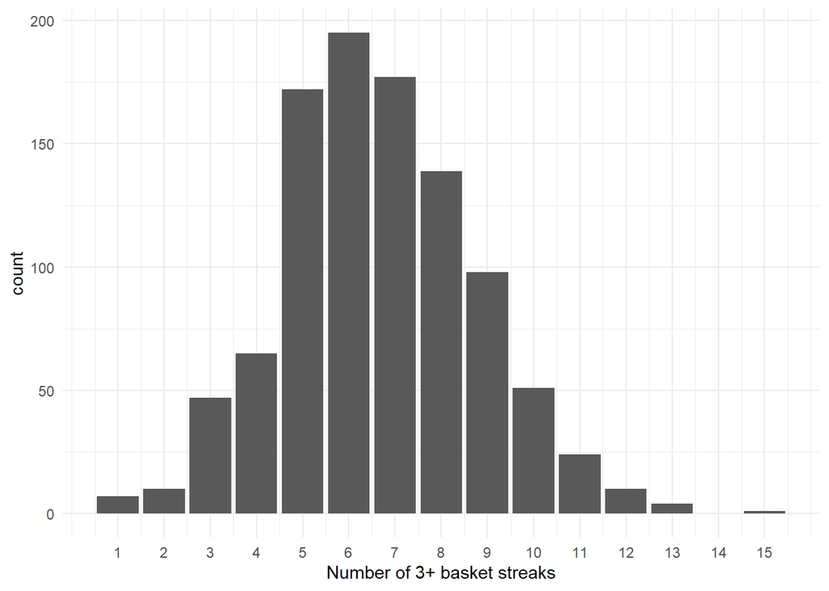

**Question #5**: Based upon the histogram above, which displays the number of 3+ basket shooting streaks from 1000 simulated independent shooters each attempting 133 shots, do you believe Kobe’s 2009 finals performance supports the existence of the *hot hand* phenomenon? (Hint: use this histogram to estimate the *probability* of seeing Kobe’s 2009 finals numbers if the independence model were true)

$~$

**Footnotes:**

<sup>This lab is adapted from the openIntro lab [published here](http://htmlpreview.github.io/?https://github.com/andrewpbray/oiLabs-base-R/blob/master/probability/probability.html), which was in-turn based upon a lab written by Mark Hansen of UCLA Statistics</sup>